# NGS Analysis Summer 2020 Course Project

yao chen

10/08/2020

# Next Generation Sequence Analysis Course Project 2020

### Differential gene expression (DGE) analysis with RNA-seq is an essential method in many areas of biology including experimental biomedicine. For your project, you will conduct a DGE analysis comparing gene expression in control breast cancer cell lines to treatment lines with a gene (NRDE2) that has been silenced with RNAi. The goal is to characterize differentially expressed genes that may be impacted by knocking down NRDE2.

### A synopsis of the experiment can be found here:

### https://www.ebi.ac.uk/ena/data/view/PRJNA490376

### The data include RNA-seq libraries from three biological replicates from control cell lines and three biological replicates in which the gene NRDE2 has been silenced with RNAi. The libraries were single-end (SE) sequenced on an Illumina NextSeq platform.

### To complete your project, you will need to process the raw data and conduct DGE with the Salmon + tximport + DESeq2 workflow introduced in the course in Week 9.

### Trim the fastqs with fastp using appropriate settings to automatically remove adapters from single end reads and polyG sequences introduced on NextSeq platforms (see Week 2)

```
#!/bin/bash
#
#SBATCH --nodes=1
#SBATCH --tasks-per-node=1
#SBATCH --cpus-per-task=1
#SBATCH --time=4:00:00
#SBATCH --mem=4GB
#SBATCH --job-name=slurm_fastp
#SBATCH --mail-type=FAIL
#SBATCH --mail-user=yc4224@nyu.edu
#SBATCH --array=1-6

module purge
module load fastp/20190829

table=/scratch/yc4224/project/project_fastqs.txt

line="$(head -n $SLURM_ARRAY_TASK_ID $table | tail -n 1)"
sample="$(printf "%s" "${line}" | cut -f1)"
fq1="$(printf "%s" "${line}" | cut -f2)"

echo Processing array index: $SLURM_ARRAY_TASK_ID sample: $sample

fqdir=/scratch/yc4224/project/fastqs

fastp=$(basename$fq1.fastq.gz).fastq.gz


fastp -i $fqdir/$fq1 -o $fastp --length_required 60  --n_base_limit 50 -a auto --trim_poly_g --html $sample.fastp.html --json $sample.fastp.json


module purge

echo _ESTATUS_ [ fastp for $sample ]: $?


# Purge fastp and load fastqc module

module purge
module load fastqc/0.11.8

# Run fastqc

fastqc $fastp

echo _ESTATUS_ [ fastqc for $sample ]: $?

echo _END_ [ fastp for $sample ]: $(date)
```

### Run fastqc on the processed RNA-seq reads separately on each sample and generate a MultiQC report.

```
find "${PWD}" -name \*fastqc.zip > fastqc_files.txt
```

```
#!/bin/bash
#
#SBATCH --nodes=1
#SBATCH --tasks-per-node=1
#SBATCH --cpus-per-task=1
#SBATCH --time=8:00:00
#SBATCH --mem=4GB
#SBATCH --job-name=fastp_array
#SBATCH --mail-type=FAIL
#SBATCH --mail-user=yc4224@nyu.edu

module purge


# Load the module

module load multiqc/intel/1.7

# Run multiqc
multiqc --file-list /scratch/yc4224/project/fastqc_files.txt
```

### g-unzip the transcripts fasta and run Picard tools NormalizeFasta to strip everything after transcript id, which is the first identifier in the Fasta header lines for each transcript.

```
gunzip Homo_sapiens.GRCh38.cdna.all.fa.gz
```

```
#!/bin/bash
#
#SBATCH --nodes=1
#SBATCH --tasks-per-node=1
#SBATCH --cpus-per-task=1
#SBATCH --time=8:00:00
#SBATCH --mem=8GB
#SBATCH --job-name=normalizefasta
#SBATCH --mail-type=FAIL
#SBATCH --mail-user=yc4224@nyu.edu

module purge

module load picard/2.8.2

java -jar "${PICARD_JAR}" NormalizeFasta \
TRUNCATE_SEQUENCE_NAMES_AT_WHITESPACE=true \
I=Homo_sapiens.GRCh38.cdna.all.fa \
O=Homo_sapiens.GRCh38.cdna.all.normalized.fa


echo _ESTATUS_ [ NormalizeFasta ]: $?
echo _END_ [ normalize_fasta.slurm ]: $(date)
```

### Create a set of index files using Salmon

https://salmon.readthedocs.io/en/latest/salmon.html

```
#!/bin/bash
#
#SBATCH --nodes=1
#SBATCH --tasks-per-node=1
#SBATCH --cpus-per-task=4
#SBATCH --time=4:00:00
#SBATCH --mem=8GB
#SBATCH --job-name=salmonindex
#SBATCH --mail-type=FAIL
#SBATCH --mail-user=yc4224@nyu.edu

module purge
module load salmon/1.3.0
module load bbmap/38.42


shuffle.sh in=Homo_sapiens.GRCh38.cdna.all.normalized.fa out=Homo_sapiens.GRCh38.cdna.all.normalized.shuffled.fa
salmon index -t Homo_sapiens.GRCh38.cdna.all.normalized.shuffled.fa -i Homo_sapiens.GRCh38.cdna.all.normalized.shuffled.fa_index -k 31
```

### Run Salmon in mapping-based mode using a command appropriate for single-end data

https://salmon.readthedocs.io/en/latest/salmon.html

[output not shown]

```
#!/bin/bash
#
#SBATCH --nodes=1
#SBATCH --tasks-per-node=1
#SBATCH --cpus-per-task=2
#SBATCH --time=4:00:00
#SBATCH --mem=16GB
#SBATCH --job-name=salmon
#SBATCH --mail-type=FAIL
#SBATCH --mail-user=yc4224@nyu.edu
#SBATCH --array=1-6

module purge

module load salmon/1.3.0

echo The array index is: ${SLURM_ARRAY_TASK_ID}

table=/scratch/yc4224/project/project_fastqs.txt
line="$(head -n ${SLURM_ARRAY_TASK_ID} "${table}" | tail -n 1)"
sample="$(printf "%s" "${line}" | cut -f2)"
fq1="$(printf "%s" "${line}" | cut -f2)"

fqdir=/scratch/yc4224/project/
salmon_index_dir=/scratch/yc4224/project/Homo_sapiens.GRCh38.cdna.all.normalized.shuffled.fa_index

mkdir $sample
cd "$sample

salmon quant -i ${salmon_index_dir} -l A -r $fqdir/$fq1 --validateMappings --gcBias --threads ${SLURM_CPUS_PER_TASK} -o $sample.transcripts_quant

echo _ESTATUS_ [ salmon quant $sample ]: $?
echo _END_ [ salmon.slurm ]: $(date)
```

### tximport requires a mapping file that maps transcript ids to genes which must be converted to imported as a data.frame (“tx2gene” in the DESeq2 vignette). This file is provided to you as a comma-delimited file:

/scratch/courses/BI7653/project.2020/tx2gene.csv

```r
library(tximport)


sample_names <- c('control1','control2','control3','treated1','treated2','treated3')
sample_condition <- c(rep('NRDE2-depleted',3),rep('control',3))

files <- file.path("salmonquant",sample_names,paste(sample_names,".transcripts_quant",sep=""),'quant.sf')
names(files) <- sample_names

tx2gene <- read.table("tx2gene.csv",header=F,sep=",")

txi <- tximport(files, type="salmon", tx2gene=tx2gene)
```

```
## reading in files with read.delim (install 'readr' package for speed up)
```

```
## 1 2 3 4 5 6
## transcripts missing from tx2gene: 2664
## summarizing abundance
## summarizing counts
## summarizing length
```

```r
samples <- data.frame(sample_names=sample_names,condition=sample_condition)
row.names(samples) <- sample_names

library("DESeq2")
ddsTxi <- DESeqDataSetFromTximport(txi,
                                   colData = samples,
                                   design = ~ condition)
```

```
##   Note: levels of factors in the design contain characters other than
##   letters, numbers, '_' and '.'. It is recommended (but not required) to use
##   only letters, numbers, and delimiters '_' or '.', as these are safe characters
##   for column names in R. [This is a message, not a warning or an error]
## using counts and average transcript lengths from tximport
```

```r
class(ddsTxi)
```

```
## [1] "DESeqDataSet"
## attr(,"package")
## [1] "DESeq2"
```

```r
dds <- DESeq(ddsTxi)
```

[output not shown]

```r
keep <- rowSums(counts(dds)) >= 10
dds <- dds[keep,]
library(ashr)
res.shrunk <- lfcShrink(dds,type='ashr',contrast = c("condition","control","NRDE2-depleted"))
```

```
## using 'ashr' for LFC shrinkage. If used in published research, please cite:
##     Stephens, M. (2016) False discovery rates: a new deal. Biostatistics, 18:2.
##     https://doi.org/10.1093/biostatistics/kxw041
```

```r
res.shrunkOrdered <- res.shrunk[order(res.shrunk$pvalue),]
res.shrunkOrdered
```

```
## log2 fold change (MMSE): condition control vs NRDE2-depleted
## Wald test p-value: condition control vs NRDE2-depleted
## DataFrame with 18632 rows and 5 columns
##                     baseMean log2FoldChange     lfcSE       pvalue         padj
##                    <numeric>      <numeric> <numeric>    <numeric>    <numeric>
## ENSG00000175334.8    6391.07        1.64652 0.0642641 2.75002e-147 4.02217e-143
## ENSG00000196396.10   6552.33        1.14929 0.0452819 2.56604e-144 1.87654e-140
## ENSG00000206286.11   2773.56       -1.38129 0.0604597 1.39324e-117 6.79249e-114
## ENSG00000163041.11   7909.36        1.65717 0.0753117 7.56192e-110 2.76502e-106
## ENSG00000105976.15   9418.09        1.52733 0.0722982 2.55800e-101  7.48265e-98
## ...                      ...            ...       ...          ...          ...
## ENSG00000281178.4    21.7413   -2.01787e+01  3.963883           NA           NA
## ENSG00000281618.1    18.6686   -1.99613e+01  4.003499           NA           NA
## ENSG00000281994.1    65.2186    5.20931e-03  0.265560           NA           NA
## ENSG00000282379.1  1560.0440    1.39254e-01  0.479361           NA           NA
## ENSG00000282735.1    55.9949    8.24706e-04  0.264535           NA           NA
```

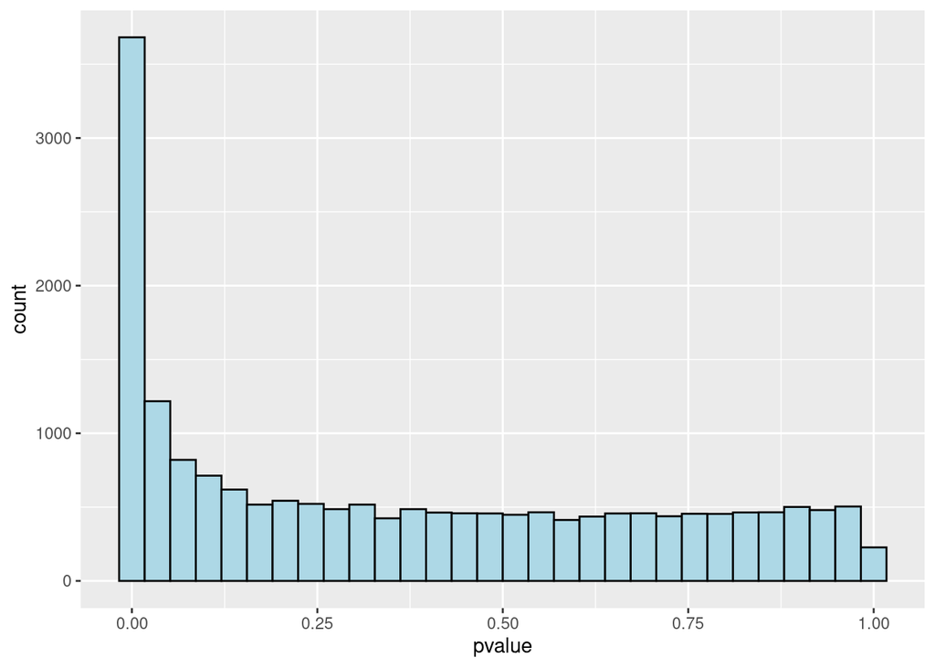

```r
library(ggplot2)
ggplot(as.data.frame(res.shrunkOrdered),aes(pvalue)) + geom_histogram(fill="light blue",color='black')
```

```r
resSig <- subset(res.shrunkOrdered, log2FoldChange > 1 & padj < 0.05, )
resSig
```

```
## log2 fold change (MMSE): condition control vs NRDE2-depleted
## Wald test p-value: condition control vs NRDE2-depleted
## DataFrame with 73 rows and 5 columns
##                     baseMean log2FoldChange     lfcSE       pvalue         padj
##                    <numeric>      <numeric> <numeric>    <numeric>    <numeric>
## ENSG00000175334.8    6391.07        1.64652 0.0642641 2.75002e-147 4.02217e-143
## ENSG00000196396.10   6552.33        1.14929 0.0452819 2.56604e-144 1.87654e-140
## ENSG00000163041.11   7909.36        1.65717 0.0753117 7.56192e-110 2.76502e-106
## ENSG00000105976.15   9418.09        1.52733 0.0722982 2.55800e-101  7.48265e-98
## ENSG00000101384.12  11619.72        1.28756 0.0618455  2.65004e-98  6.45991e-95
## ...                      ...            ...       ...          ...          ...
## ENSG00000258466.5    40.2644        1.74207  1.602236  1.27462e-05  0.000167499
## ENSG00000111181.12   29.5704        1.20527  0.828978  2.09120e-05  0.000261319
## ENSG00000182050.13   63.1691        1.20840  1.096918  2.64044e-05  0.000320757
## ENSG00000153404.14   56.6026        1.00060  0.478548  3.19219e-05  0.000381135
## ENSG00000100505.13   36.4292        1.04556  0.739345  4.15320e-05  0.000477177
```

```r
dds <- estimateDispersions(dds,fitType = c("parametric"))
```

[output not shown]

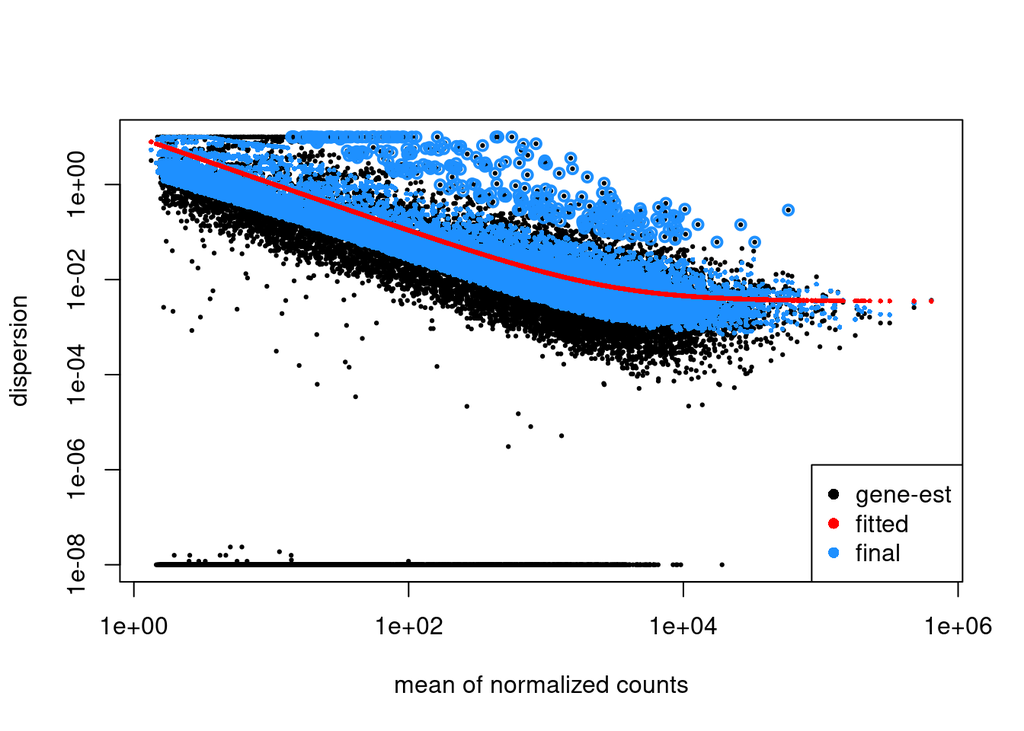

```r
plotDispEsts(dds)
```

```r
dds <- DESeq(dds)
```

```
## found already estimated dispersions, replacing these
```

```
##   Note: levels of factors in the design contain characters other than
##   letters, numbers, '_' and '.'. It is recommended (but not required) to use
##   only letters, numbers, and delimiters '_' or '.', as these are safe characters
##   for column names in R. [This is a message, not a warning or an error]
```

```
##   Note: levels of factors in the design contain characters other than
##   letters, numbers, '_' and '.'. It is recommended (but not required) to use
##   only letters, numbers, and delimiters '_' or '.', as these are safe characters
##   for column names in R. [This is a message, not a warning or an error]
```

```r
rawcounts.matrix <- counts(dds,normalized=F)
normalizedcounts.matrix <- counts(dds,normalized=T)
class(rawcounts.matrix)
```

```
## [1] "matrix" "array"
```

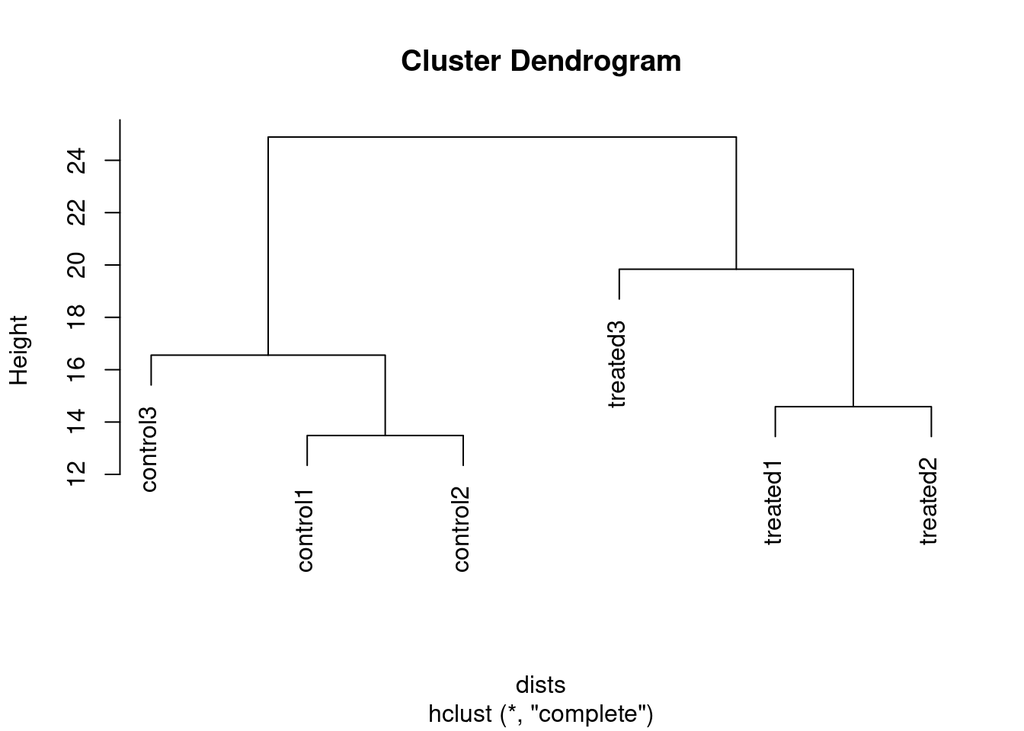

```r
rld <- rlog(dds)
dists <- dist(t(assay(rld)))
plot(hclust(dists))
```

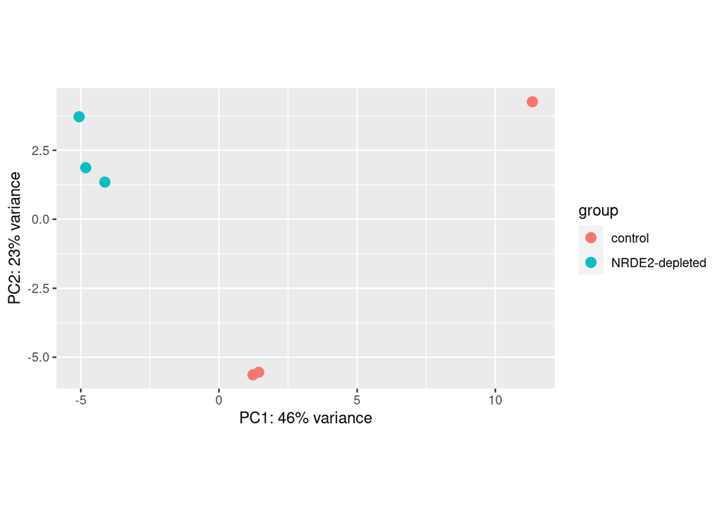

```r
plotPCA(rld)
```

```r
res <- results(dds, contrast = c('condition','control','NRDE2-depleted') )
class(res)
```

```
## [1] "DESeqResults"
## attr(,"package")
## [1] "DESeq2"
```

```r
resOrdered <- res[order(res$pvalue),]
head(resOrdered,10)
```

```
## log2 fold change (MLE): condition control vs NRDE2-depleted
## Wald test p-value: condition control vs NRDE2-depleted
## DataFrame with 10 rows and 6 columns
##                     baseMean log2FoldChange     lfcSE      stat       pvalue
##                    <numeric>      <numeric> <numeric> <numeric>    <numeric>
## ENSG00000196396.10   6552.33        1.15645 0.0424401   27.2489 1.71216e-163
## ENSG00000175334.8    6391.07        1.66022 0.0628037   26.4351 5.41402e-154
## ENSG00000206286.11   2773.56       -1.39350 0.0580143  -24.0199 1.72171e-127
## ENSG00000163041.11   7909.36        1.67594 0.0745530   22.4798 6.54166e-112
## ENSG00000105976.15   9418.09        1.54474 0.0714668   21.6147 1.30553e-103
## ENSG00000101384.12  11619.72        1.30039 0.0605205   21.4868 2.06804e-102
## ENSG00000124333.16   2719.53        1.49588 0.0715503   20.9067  4.65572e-97
## ENSG00000128595.17  22621.17        1.47473 0.0705556   20.9017  5.16813e-97
## ENSG00000117632.23  16619.17        1.35041 0.0667999   20.2158  7.11177e-91
## ENSG00000213281.5    6883.00        1.18936 0.0624122   19.0566  5.79447e-81
##                            padj
##                       <numeric>
## ENSG00000196396.10 2.44309e-159
## ENSG00000175334.8  3.86263e-150
## ENSG00000206286.11 8.18905e-124
## ENSG00000163041.11 2.33357e-108
## ENSG00000105976.15 3.72572e-100
## ENSG00000101384.12  4.91814e-99
## ENSG00000124333.16  9.21800e-94
## ENSG00000128595.17  9.21800e-94
## ENSG00000117632.23  1.12753e-87
## ENSG00000213281.5   8.26813e-78
```

```r
summary(res)
```

```
##
## out of 18632 with nonzero total read count
## adjusted p-value < 0.1
## LFC > 0 (up)       : 2194, 12%
## LFC < 0 (down)     : 1953, 10%
## outliers [1]       : 43, 0.23%
## low counts [2]     : 4320, 23%
## (mean count < 30)
## [1] see 'cooksCutoff' argument of ?results
## [2] see 'independentFiltering' argument of ?results
```

```r
library(ashr)
res.shrunk <- lfcShrink(dds,type='ashr',contrast = c("condition",'control','NRDE2-depleted'))
```

```
## using 'ashr' for LFC shrinkage. If used in published research, please cite:
##     Stephens, M. (2016) False discovery rates: a new deal. Biostatistics, 18:2.
##     https://doi.org/10.1093/biostatistics/kxw041
```

```r
res.shrunkOrdered <- res.shrunk[order(res.shrunk$pvalue),]


resOrdered
```

```
## log2 fold change (MLE): condition control vs NRDE2-depleted
## Wald test p-value: condition control vs NRDE2-depleted
## DataFrame with 18632 rows and 6 columns
##                     baseMean log2FoldChange     lfcSE       stat       pvalue
##                    <numeric>      <numeric> <numeric>  <numeric>    <numeric>
## ENSG00000196396.10   6552.33        1.15645 0.0424401    27.2489 1.71216e-163
## ENSG00000175334.8    6391.07        1.66022 0.0628037    26.4351 5.41402e-154
## ENSG00000206286.11   2773.56       -1.39350 0.0580143   -24.0199 1.72171e-127
## ENSG00000163041.11   7909.36        1.67594 0.0745530    22.4798 6.54166e-112
## ENSG00000105976.15   9418.09        1.54474 0.0714668    21.6147 1.30553e-103
## ...                      ...            ...       ...        ...          ...
## ENSG00000281178.4    21.7413     -21.135176   3.90867 -5.4072566           NA
## ENSG00000281618.1    18.6686     -20.926067   3.90898 -5.3533263           NA
## ENSG00000281994.1    65.2186       1.032160   3.72814  0.2768566           NA
## ENSG00000282379.1  1560.0440       4.695096   1.72765  2.7176234           NA
## ENSG00000282735.1    55.9949       0.163838   3.72831  0.0439443           NA
##                            padj
##                       <numeric>
## ENSG00000196396.10 2.44309e-159
## ENSG00000175334.8  3.86263e-150
## ENSG00000206286.11 8.18905e-124
## ENSG00000163041.11 2.33357e-108
## ENSG00000105976.15 3.72572e-100
## ...                         ...
## ENSG00000281178.4            NA
## ENSG00000281618.1            NA
## ENSG00000281994.1            NA
## ENSG00000282379.1            NA
## ENSG00000282735.1            NA
```

```r
res.shrunkOrdered
```

```
## log2 fold change (MMSE): condition control vs NRDE2-depleted
## Wald test p-value: condition control vs NRDE2-depleted
## DataFrame with 18632 rows and 5 columns
##                     baseMean log2FoldChange     lfcSE       pvalue         padj
##                    <numeric>      <numeric> <numeric>    <numeric>    <numeric>
## ENSG00000196396.10   6552.33        1.15018 0.0424999 1.71216e-163 2.44309e-159
## ENSG00000175334.8    6391.07        1.64708 0.0628254 5.41402e-154 3.86263e-150
## ENSG00000206286.11   2773.56       -1.38223 0.0580214 1.72171e-127 8.18905e-124
## ENSG00000163041.11   7909.36        1.65743 0.0745937 6.54166e-112 2.33357e-108
## ENSG00000105976.15   9418.09        1.52766 0.0714735 1.30553e-103 3.72572e-100
## ...                      ...            ...       ...          ...          ...
## ENSG00000281178.4    21.7413   -2.01788e+01  3.963725           NA           NA
## ENSG00000281618.1    18.6686   -1.99614e+01  4.003306           NA           NA
## ENSG00000281994.1    65.2186    5.21558e-03  0.265715           NA           NA
## ENSG00000282379.1  1560.0440    1.38906e-01  0.477114           NA           NA
## ENSG00000282735.1    55.9949    8.25716e-04  0.264696           NA           NA
```

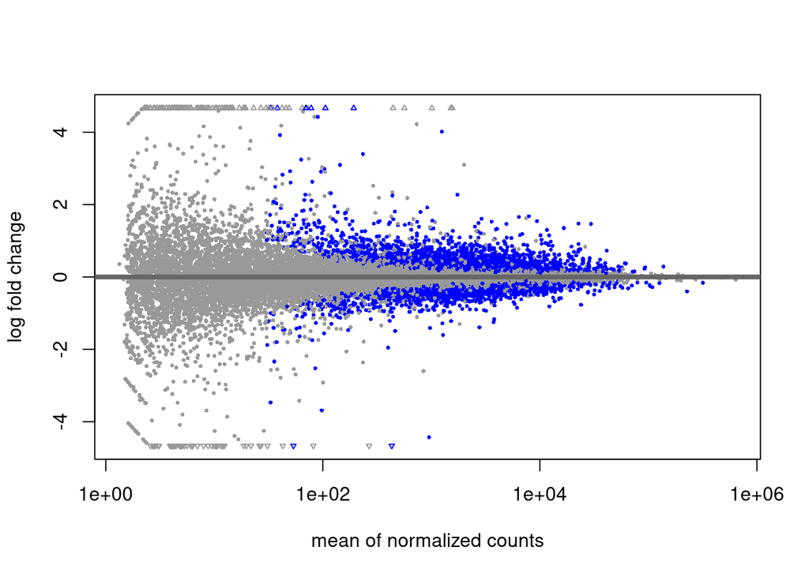

```r
plotMA(res)
```

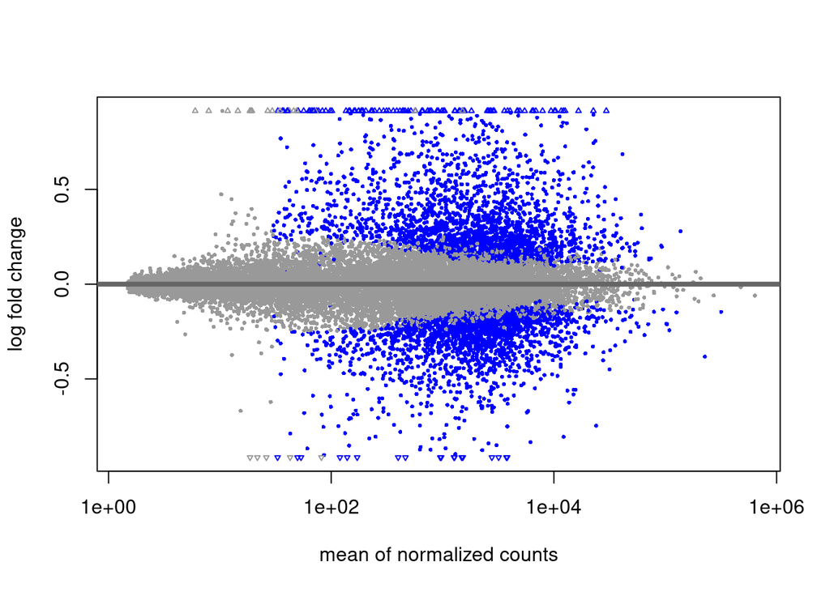

```r
plotMA(res.shrunk)
```

```r
resSig <- subset(res.shrunkOrdered, log2FoldChange > 1 & padj < 0.05, )
resSig
```

```
## log2 fold change (MMSE): condition control vs NRDE2-depleted
## Wald test p-value: condition control vs NRDE2-depleted
## DataFrame with 72 rows and 5 columns
##                     baseMean log2FoldChange     lfcSE       pvalue         padj
##                    <numeric>      <numeric> <numeric>    <numeric>    <numeric>
## ENSG00000196396.10   6552.33        1.15018 0.0424999 1.71216e-163 2.44309e-159
## ENSG00000175334.8    6391.07        1.64708 0.0628254 5.41402e-154 3.86263e-150
## ENSG00000163041.11   7909.36        1.65743 0.0745937 6.54166e-112 2.33357e-108
## ENSG00000105976.15   9418.09        1.52766 0.0714735 1.30553e-103 3.72572e-100
## ENSG00000101384.12  11619.72        1.28806 0.0605639 2.06804e-102  4.91814e-99
## ...                      ...            ...       ...          ...          ...
## ENSG00000163879.11  101.4917        1.01885  0.331425  3.20063e-06  4.57614e-05
## ENSG00000258466.5    40.2644        1.54701  1.562756  1.78443e-05  2.15051e-04
## ENSG00000153404.14   56.6026        1.00706  0.475916  2.97507e-05  3.36915e-04
## ENSG00000182050.13   63.1691        1.07153  1.052964  3.88330e-05  4.26893e-04
## ENSG00000100505.13   36.4292        1.02235  0.733746  4.53106e-05  4.90172e-04
```

```r
write.table(as.data.frame(resSig),
          file="condition_treated_results.tsv",sep = "\t")
```